# Deep Learning - 課程 32 - An Introduction to MobileNet V2V3 Images 圖像 目標檢測 - Python Tutorial

''' 人工智慧- 進階課程 A.I Tutorials - Advanced Course - Deep Learning 教程 ''' 05 - 深度學習 教程 課程 32 - An introduction to MobileNet V2V3 程式範例 - MobileNetV2 Object Detection Images - Fashion_Mnist 圖像 目標檢測 '''

''' >> 資料準備 >> 你我互動學習園地- 進階課程 Advanced Course >> https://interactiveuandmetutorialsac.weebly.com/ >> 你我互動學習園地 >> https://interactiveuandmetutorials.weebly.com/ >> Python 程式語言 設計 >> https://pythonprogrammingtutorials.weebly.com/ >> 目錄結構 : >> 課程 32 - Deep Learning- An introduction to MobileNet V2V3.zip 檔案路徑/ ├── 課程 32 - Deep Learning- An introduction to MobileNet V2V3 .ipynb ├── MobileNet-Images/ | ├── dog.jpg | ├── eagle.png | ├── person.jpg | ├── | └── zebra.jpg ├── MobileNet-inference-images | ├── dog.jpg | ├── eagle.png | ├── person.jpg | ├── images.jpg | └── zebra.jpg └── data/ '''

[figure not shown]

- MobileNets- Paper 論文參考
  - https://arxiv.org/abs/1704.04861
  - https://arxiv.org/pdf/1704.04861.pdf
- MobileNetV2- Paper 論文參考
  - https://arxiv.org/abs/1801.04381
  - https://arxiv.org/pdf/1801.04381.pdf
- MobileNetV3- Paper 論文參考
  - https://arxiv.org/abs/1905.02244
  - https://arxiv.org/pdf/1905.02244.pdf

## MobileNetV1

- 引入 深度可分離卷積 Depth-wise Separable Convolutions Architecture
  - 可以顯著 降低網絡的複雜性成本 和 模型大小
- 適用於 移動設備 或 任何計算能力低 的設備 Device

## MobileNetV2

- Inverted Residuals and Linear Bottlenecks
- 反向殘差 和 線性瓶頸

## MobileNetV2

```
- 引入一種更好的具有 反向殘差 結構的模塊
  - 消除了窄層中的 非線性

- MobileNetV2 作為特徵提取的主幹
- 適用於
  - 對象檢測 和 語義分割的最新 性能
```

## - MobileNetV2 用於分類，檢測

[figure not shown]

## MobileNetV2 與 MobileNets(V1) 相比較

### 總體而言

[output not shown]

[figure not shown]

''' Model Params Multily-Adds mAP Mobile CPU MobileNetV1 + SSDLite 5.1M 1.3B 22.2% 270ms MobileNetV2 + SSDLite 4.3M 0.8B 22.1% 220ms '''

- Google 在 2017年 提出的 MobileNet Model 模型
  - 主要是 因為隨著深度學習的快速發展模型 不但深又巨大
  - 整體參數很可觀 - (比較 流行的模型 幾乎 都以 千萬個參數 為 單位)
  - 而加減乘法運算(Multiplications and Accumulations) 更可以 達到數十億 為單位 的 計算量
  - 這麼 大的模型
  - 不太能在 Mobile/Portable Device 運用
  - 在沒有 大量 GPU幫助下
  - 手機 或 是 即時翻譯 機
  - 無法做到 很好的 Real Time Implementation
- 在大的網路模型中
  - 大部分的計算量都發生在卷積（convolution）計算中
  - 因此
  - 深度可分離卷積神經網絡 Depth-Wise Separable Convolutions Networks
  - 提出來
    - 在不減低太多性能狀態下
    - 盡量減少 原始卷積的計算量

# MobileNets：應用於 移動視覺 高效能 的 卷積神經網絡

- MobileNets: Efficient Convolutional Neural Networks for Mobile Vision Applications

# MobileNets

- 移動 和 嵌入式 視覺應用
- Mobile and Embedded Vision Applications

# MobileNets are based on a Streamlined Architecture

- 基於 精簡架構 體系結構 - Streamlined Architecture
- 模型結構
  - 使用深度方向可分離卷積 Depth-Wise Separable Convolutions
  - 來構建
  - 輕型深度神經網絡 Light Weight Deep Neural Networks

# MobileNets Architecture 基於簡化的 體系結構

```
- 深度方向可分離卷積神經網絡  Depth-Wise Separable Convolutions
```

## MobileNets架構 MobileNets Architecture

```
- 有效地在 延遲 和 準確性 之間 - 進行權衡
- Trade Off Between Latency and Accuracy
```

[figure not shown]

## MobileNetV1

- MobileNetV1
  - 有2層
  - 第一層 稱為深度方向卷積
    - 它通過施加每個輸入信道的單個卷積濾波器執行輕量過濾。
  - 第二層 稱為是一個1×1的卷積，稱為逐點卷積
    - 這是負責通過計算線性輸入信道的組合建立新的特徵
  - ReLU6
    - （實際上，在MobileNetV1技術報告中，我找不到他們使用ReLU6的任何提示……也許我們需要檢查Github中的代碼……）
    - min（max（x，0），6）
- 深度可分離卷積 的計算
  - 是希望 在不影響輸出結構的狀態下 減少運算量
  - 基本上可以 拆成兩部分
    1. 深度卷積 Depthwise convolution
    2. 點向卷積 Pointwise convolution
- 深度可分離卷積架構 Depth-wise Separable Convolutions Architecture

[figure not shown]

- 深度可分離卷積的計算是希望在不影響輸出結構的狀態下減少運算量
  - 基本上可以拆成兩部分
    1. 深度卷積 Depthwise convolution
    2. 點向卷積 Pointwise convolution
- 卷積運算 - Convolution operation

[figure not shown]

- 輸入資料 : W_in *H_in* Nch (輸入圖的寬*高*輸入channel數)
- Kernel Map : k *k* Nk (Kernel map 寬*高*kernel數，kernel寬高假設一樣)
- 輸出資料 : W_out *H_out* Nk (輸出圖的寬*高*輸出channel數)

[figure not shown]

- 深度可分離卷積的計算是希望在不影響輸出結構的狀態下減少運算量
  - 基本上可以拆成兩部分
    1. 深度卷積 Depthwise convolution
    2. 點向卷積 Pointwise convolution
- 1. 深度卷積 Depthwise convolution
     - 針對輸入資料的每一個Channel都建立一個 k * k 的內核
     - 然後每一個 Channel 針對對應的 Kernel都各自（分開）做卷積
     - 和一般卷積不太一樣
       - 一般的捲積計算
         - 是每個內核映射都要和所有 channel 都去做 convolution
         - 這理是 分開獨立去處理

[figure not shown]

- 1. 點向卷積 Pointwise Convolution
     - 輸入資料 - 每個通道做完 Depthwise卷積後 -針對每個點的所有通道

       ```
        - Pointwise 卷積
       ```

     - 回顧複習一下 1×1 的捲積 先
- 1×1 的捲積
  - 1×1捲積 是在 作降維 或是 提高維度用
  - 1×1卷積 也在 處理 channel之間 的合成

[figure not shown]

- 點向卷積 Pointwise Convolution
  - 輸入資料 - 每個通道做完 Depthwise卷積後 -針對每個點的所有通道
  - Pointwise 卷積
- 建立N k個1 *1* N ch的內核映射
  - 將 Depthwise卷積的輸出 做一般1 * 1的 捲積計算

[figure not shown]

- 計算
  - 1.深度卷積 Depthwise convolution : -輸入資料：W *in * H* in *N ch -做每個輸入通道相對應的內核映射（k* k）的捲積
    - 輸出大小為W *out * H* out * N ch
  - 2.點向卷積 Pointwise Convolution： -輸入資料：W *out * H* out *N ch -做一般N k個內核映射（1* 1）的捲積 -輸出大小：W *out * H* out * N k
  - 深度可分離卷積

[figure not shown]

- 計算量 -輸入資料 ：W *in * H* in * N ch
  - 內核圖 ：k *k* N k
  - 輸出資料：W *out * H* out * N k
    - 一般卷積計算量為 W *in * H* in *N ch* k *k* N k
- 深度可分離卷積計算量為
  - Depthwise convolution 計算量 + Pointwise convolution計算量
    - 深度卷積計算量
      - W *in * H* in *N ch* k * k
    - 點向卷積計算量
      - N ch *N k* W *in * H* in
- 當內核映射數量和內核映射數量越多
  - 深度可分離卷積可以節省越多計算量
  - 假設
    - IMput 輸入 - 416 *416* 50
    - Filter - 10個 大小為3 * 3的內核圖
  - 深度可分離卷積 只有一般卷積的
    - 1/10 + 1/9 = 0.211計算量

[figure not shown]

# MobileNetV1 Architecture 架構

```
-  Batch Normalization (BN) and ReLU are applied after each convolution
```

[figure not shown]

- 每次卷積後 都使用 歸一化( Batch Normalization BN 和 (ReLU)
- Batch Normalization (BN) and ReLU are applied after each convolution

[figure not shown]

## ReLU6具有 魯棒性 / 穩定性

[figure not shown]

## MobileNet

- 什麼是 深度方向可分離卷積神經網絡 Depth-Wise Separable Convolutions Netwaork
- 深度可分離卷積架構 Depth-wise Separable Convolutions Architecture

[figure not shown]

- 輸入資料 : W_in *H_in* Nch (輸入圖的寬*高*輸入channel數)
- Kernel Map : k *k* Nk (Kernel map 寬*高*kernel數，kernel寬高假設一樣)
- 輸出資料 : W_out *H_out* Nk (輸出圖的寬*高*輸出channel數)

[figure not shown]

## MoblileNet V2

### MoblileNet V2 的初始構建塊中

```
- 添加了 壓縮層 和 激勵層
```

- MoblileNet V2
  - MobileNetV1 引入了深度卷積以減少參數數量
- MoblileNet V2 添加了一個擴展層
  - V2的初始構建塊中添加了壓縮層 squeeze 和 激勵層 excitation
  - 使用這三個層
    - 擴展 Expansion- 過濾 Filtering - 壓縮系統 Compression
  - 反向殘差塊 Inverted Residual Block
- MobileNetV2 用於分類，檢測

```
- MobileNetV1
```

[figure not shown]

```
- MobileNetV2
```

[figure not shown]

- MobileNetV1 & MobileNetV2

[figure not shown]

# MobileNetV1 卷積模塊

- MobileNetV1 卷積模塊 中有2層
  - 第一層 被稱為 深度方向卷積
    - 它通過每個輸入信道 的單個卷積濾波器
      - 執行輕量過濾
  - 第二層 是一個 1×1 的卷積
  - 稱為 逐點卷積
  - 這是
    - 負責 通過 計算 線性輸入信道的 組合建立新的特徵
  - ReLU6 在這裡用於比較
  - 實際上
    - 在 MobileNetV1技術報告中
    - 找不到
      - 使用ReLU6的任何提示
      - ……也許我們需要檢查Github中的代碼……），即min（max（x，0），6）如下：

[figure not shown]

## MobileNetV2 卷積模塊

- MobileNetV2 中，有 兩種類型的塊 Block
  - 一個是 步幅為1的 剩餘塊
  - 另一個是 步幅為2 的塊 以縮小尺寸
- 兩種類型的 塊 Block 都有3層
- 第一層 ReLU6 的 1×1 卷積
- 第二層 深度方向 上卷積 Upsamples
- 第三層 是另一個 1×1卷積 但沒有任何非線性
- ReLU
  - 深度網絡 僅在輸出部分 具有線性分類器的功能

[figure not shown]

- 個膨脹因子 t
  - 主要實驗，t = 6
  - 如果輸入有64個通道
  - 則內部輸出
    - 64 × t = 64 × 6 = 384個 通道

## MobileNetV2 架構

[figure not shown]

- t：擴展因子
- c：輸出通道數
- n：重複數
- s：步幅
- 3×3 內核 用於空間卷積
- 主網絡(寬度 乘法器 1，224×224 ) - 的計算成本 為 3億次 乘法運算
- 使用340萬個 參數
- MobileNetV1 中 引入了 寬度乘數
- 對於輸入分辨率從 96 到 224
- 寬度乘數為 0.35 到 1.4的性能
- 進一步 權衡取捨
- Network 網絡
  - 計算成本高達585M MAdds
- 模型大小在 1.7M 和 6.9M參數 之間變化

[figure not shown]

# MoblileNet V2

```
- Mobile Net V2建立在MobileNet V1 [1]的思想的基礎上，使用深度智能可分離卷積作為有效的構建塊。但是，V2向該體系結構引入了兩個新功能：1）層之間的線性瓶頸，以及2）瓶頸之間的短連接
```

[figure not shown]

- MoblileNet V2
  - MobileNetV1 引入了深度卷積以減少參數數量
- MoblileNet V2 添加了一個擴展層
  - V2的初始構建塊中添加了壓縮層 squeeze 和 激勵層 excitation
  - 使用這三個層
    - 擴展 Expansion- 過濾 Filtering - 壓縮系統 Compression
  - 反向殘差塊 Inverted Residual Block

[figure not shown]

# MobileNet V3

- MobileNet V3 加入 AutoML
- MobileNet V3 架構
  - Searching for MobileNetV3
  - https://arxiv.org/abs/1905.02244
  - 兩種 AutoML 技術
  - MnasNet
    - 一種自動移動神經體系結構搜索（MNAS）方法
    - https://research.google/pubs/pub47217/
    - NetAdapt
    - 適用於移動應用程序的平臺感知型算法
    - https://arxiv.org/pdf/1804.03230.pdf
- 結合硬件感知的網絡體系結構搜索(MNAS) + NetAdapt 演算法
  - MobileNet V3被調整到手機CPU
  - 隨後 通過結構優勢 進行了改進
- Architecture Search
  - Neural Architecture Search (NAS)
- 試圖 使模型 (通常稱為 RNN，也稱為控制器 )
  - 輸出 模塊 執行的過程
  - 可以
  - 將這些模塊 放在一起形成一個模型
- 該模型
  - 在所有可能的組合中搜索
  - 提供最佳精度的組合

[figure not shown]

## MobileNetV3 的另一個新穎想法

- 是在架構中加入一種名爲「Squeeze-and-Excitation」的神經網絡 (簡稱 SE-Net )

### SE-Net 神經網絡

- 核心思想 是 通過 顯式地 建模 網絡卷積特徵通道之間的相互依賴關係
- 來提高 網絡所產生 (表示特徵) 的品質量

### 具體來說

```
- 就是通過學習 來自動獲取到每個特徵通道 的重要程度
- 然後
- 依照 這結果
  - 去提升有用的特徵 並抑制對當前 用處不大的特徵
  - 提出了一種 允許 網絡 進行特徵重新校準 的機制
```

- MobileNetV3
  - 首先使用 MnasNet 進行粗略結構的搜索
  - 然後
    - 使用強化學習
    - 從一組離散的選擇中 選擇 最優 配置
    - 之後
    - MobileNetV3 再使用 NetAdapt 對體系結構 進行微調
  - 實現現了 NetAdapt 的補充功能
    - 它能夠以較小的降幅
    - 對未充分利用的激活通道
    - 進行調整
- NetAdapt 用於分層 智能搜索
  - 演算法 用於 每個轉化的 過濾器數量

[figure not shown]

## MobileNetV3 中還有一個的優化

- 是重新設計
  - 體系結構中一些運行成本較高的層
  - MobileNetV2 中 的一些層是模型準確性的基礎
  - 但也引入了潛在變量
  - 通過合併一些基本的優化功能
- MobileNetV3 能夠在不犧牲 準確性的情況下
  - 刪除 MobileNetV2 體系結構中
  - 三個運行成本較高的層
- 1.0 去除層
- 2.0 非線性

[figure not shown]

- MobileNetV3 相比以前的架構有了顯著的改進
- 例如
- 在目標檢測任務中
  - MobileNetV3 的操作延遲在減少 25% 的同時
  - 維持和以前版本相同的精度

[figure not shown]

# 程式範例

```python
%matplotlib inline
```

- 忽略 警告訊息 Warning Message

```python
import warnings
warnings.filterwarnings("ignore")
```

- 檢查是否 - 有 GPU

```python
from tensorflow.python.client import device_lib
print (device_lib.list_local_devices())
```

```
[name: "/device:CPU:0"
device_type: "CPU"
memory_limit: 268435456
locality {
}
incarnation: 10817748740862836781
, name: "/device:GPU:0"
device_type: "GPU"
memory_limit: 3176441446
locality {
  bus_id: 1
  links {
  }
}
incarnation: 12158298804865906435
physical_device_desc: "device: 0, name: GeForce GTX 980M, pci bus id: 0000:01:00.0, compute capability: 5.2"
]
```

- os.environ 在 Jupyter Notebok 中 - 設置環境變量
- 初始化TensorFlow
  - 將 TensorFlow 限制為第一個GPU之前

```python
import os
os.environ["CUDA_DEVICE_ORDER"]="PCI_BUS_ID"   # see issue #152
os.environ["CUDA_VISIBLE_DEVICES"]="0"
```

```python
!python -V
```

```
Python 3.6.7
```

```python
import keras
print(keras.__version__)
```

```
2.2.4
```

- 準備訓練數據
- Prepare Training Data

| 標籤 | 說明 |
| --- | --- |
| 0 | T卹/上衣 |
| 1 | 褲子 |
| 2 | 套頭衫 |
| 3 | 連衣裙 |
| 4 | 大衣 |
| 5 | 涼鞋 |
| 6 | 襯衫 |
| 7 | 運動鞋 |
| 8 | 包袋 |
| 9 | 腳踝靴 |

| Label | Description |
| --- | --- |
| 0 | T-shirt/top |
| 1 | Trouser |
| 2 | Pullover |
| 3 | Dress |
| 4 | Coat |
| 5 | Sandal |
| 6 | Shirt |
| 7 | Sneaker |
| 8 | Bag |
| 9 | Ankle boot |

- 導入 Fashion-mnist 訓練數據 和 測試數據

```python
from keras.datasets.fashion_mnist import load_data

(x_train, y_train), (x_test, y_test) = load_data()

print("X_train shape:", x_train.shape)
print("Y_train shape:", y_train.shape)
```

```
X_train shape: (60000, 28, 28)
Y_train shape: (60000,)
```

- 定義 顯示圖像 的 輔助函數
  - def show_images(images)

```python
import matplotlib.pyplot as plt
import numpy as np
%matplotlib inline

def show_images(images):
    """
    圖像 Images : numpy arrays
    """
    n_images = len(images)
    titles = ['(%d)' % i for i in range(1, n_images + 1)]
    num = 5
    iter_num = np.ceil(n_images / num).astype(int)
    for i in range(iter_num):
        fig = plt.figure()
        sub_images = images[i * num:num * (i + 1)]
        sub_titles = titles[i * num:num * (i + 1)]
        for n, (image, title) in enumerate(zip(sub_images, sub_titles)):
            a = fig.add_subplot(1, np.ceil(len(sub_images)), n + 1)
            if image.ndim == 2:
                plt.gray()
            a.set_title(title, fontsize=15)
            plt.imshow(image)
```

- 檢查 / 顯示 數據樣本

[figure not shown]

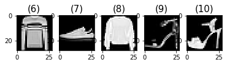

```python
show_images(x_train[:10])
```

- 數據標準化 - Data Normalization
- 歸一化 數據維度
- 使其具有 大致相同的 規模
  - 歸一化使非常深的NN更易於訓練
  - 在卷積神經網絡中 特別明顯

[figure not shown]

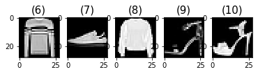

```python
norm_x_train = x_train.astype('float32') / 255
norm_x_test  = x_test.astype ('float32') / 255

show_images(norm_x_train[:10])
```

## One Hot Encoding - 熱編碼

- 熱編碼
- 將分類變量 Categorical Variables
- 轉換為 二進制向量 Binary Vectors

```python
from keras.utils import to_categorical
encoded_y_train = to_categorical(y_train, num_classes=10, dtype='float32')
encoded_y_test  = to_categorical(y_test , num_classes=10, dtype='float32')
```

```python
encoded_y_train[0:10]
```

```
array([[0., 0., 0., 0., 0., 0., 0., 0., 0., 1.],
       [1., 0., 0., 0., 0., 0., 0., 0., 0., 0.],
       [1., 0., 0., 0., 0., 0., 0., 0., 0., 0.],
       [0., 0., 0., 1., 0., 0., 0., 0., 0., 0.],
       [1., 0., 0., 0., 0., 0., 0., 0., 0., 0.],
       [0., 0., 1., 0., 0., 0., 0., 0., 0., 0.],
       [0., 0., 0., 0., 0., 0., 0., 1., 0., 0.],
       [0., 0., 1., 0., 0., 0., 0., 0., 0., 0.],
       [0., 0., 0., 0., 0., 1., 0., 0., 0., 0.],
       [0., 0., 0., 0., 0., 1., 0., 0., 0., 0.]], dtype=float32)
```

```python
encoded_y_test[0:10]
```

```
array([[0., 0., 0., 0., 0., 0., 0., 0., 0., 1.],
       [0., 0., 1., 0., 0., 0., 0., 0., 0., 0.],
       [0., 1., 0., 0., 0., 0., 0., 0., 0., 0.],
       [0., 1., 0., 0., 0., 0., 0., 0., 0., 0.],
       [0., 0., 0., 0., 0., 0., 1., 0., 0., 0.],
       [0., 1., 0., 0., 0., 0., 0., 0., 0., 0.],
       [0., 0., 0., 0., 1., 0., 0., 0., 0., 0.],
       [0., 0., 0., 0., 0., 0., 1., 0., 0., 0.],
       [0., 0., 0., 0., 0., 1., 0., 0., 0., 0.],
       [0., 0., 0., 0., 0., 0., 0., 1., 0., 0.]], dtype=float32)
```

## 調整圖像大小

- 轉換 為 3通道 (RGB)
- MobileNet V2 model
- 接受 圖像 輸入格式:
- (96, 96), (128, 128), (160, 160),(192, 192), or (224, 224). In addition, the image has to be 3 channel (RGB) format.
- 調整圖像大小 從(28 X 28) 到(96 X 96 X 3)

```python
from skimage.transform import resize

target_size = 96

def preprocess_image(x):

    # Resize the image t調整圖像大小 從(28 X 28) 到 (96 X 96 X 3)
    x = resize(x, (target_size, target_size),
                   mode='constant',
                   anti_aliasing=False)

    # 轉換 為 3 通道 (RGB)
    x = np.stack((x,)*3, axis=-1)

    # Float32
    # tf.float64 比 tf.float32 提供 更高的 分辨率
    # tf.float32允許在內存中 存儲 更多內容 (2次 Double)
    return x.astype(np.float32)
```

## Python Generator 是一個返回對象（迭代器）的函數

- 可以對數據數據中運行 其進行迭代(一次一個值)
- 減少量內存資源使用

```python
from sklearn.utils import shuffle
def load_data_generator(x, y, batch_size=64):
    num_samples = x.shape[0]
    while 1:
        try:
            shuffle(x)
            for i in range(0, num_samples, batch_size):
                x_data = [preprocess_image(im) for im in x[i:i+batch_size]]
                y_data = y[i:i + batch_size]

                # 轉換 成 numpy array
                yield shuffle(np.array(x_data), np.array(y_data))
        except Exception as err:
            print(err)
```